# Is Programming Relevant to CS1 Students’ Interests?

Kevin Buffardi and Subhed Chavan

## Presentation

This is a brief summary of *Is Programming Relevant to CS1 Students’ Interests?*, presented at [Consortium for Computing Sciences in Colleges, Northwest 2021](http://www.ccsc.org/northwest/2021/) and published in the [Journal of Computing Sciences in Colleges, Volume 7, Number 1](https://www.ccsc.org/publications/journals/NW2021.pdf).

This presentation page is available at [kbuffardi.github.io/interests](https://kbuffardi.github.io/interests/) and its source is available on [GitHub](https://github.com/kbuffardi/interests/).

### Full Paper

The full paper is available via ACM Digital library *(link coming soon)*

To cite this paper, use the following bibliography:

> Bibliographic entry coming soon

Or import the following *BibTeX* reference:

> BibTeX reference coming soon

## Preface: Is bowling one of your hobbies or interests?

[figure not shown]

Bowling ball and pins

### Who do you picture as a bowler?

Based on Google image searches alone, bowling might not be particularly diverse:

[figure not shown]

### Why ask?

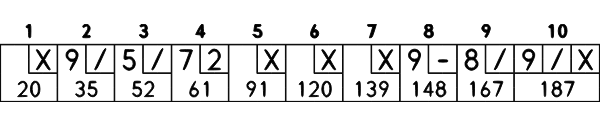

Bowling score card

A **bowling score calculator is a prototypical assignment** for introductory programming courses.

However, it may also be the epitome of an application of coding that **lacks broad appeal** and may **reinforce stereotypes** of coding classes’ target audiences.

## Research Questions

Investigated the following research questions:

1. What *popular interests* do students perceive as **relevant** to CS/coding?
2. What *popular interests* do students perceive as **not relevant** to CS/coding?
3. Are there differences in **how interested different genders and races** are in common CS1 applications?
4. Are there interests that **uniquely appeal to gender and racial minorities**?

## Method

At **California State University-Chico** (Chico State)

- Predominantly undergraduate institution
- Hispanic-Serving Institution
- Computer Science department, within *College of Engineering, Computer Science, & Construction Management* (ECC)

We surveyed students in a **CS1 course**

- CSCI 111 - Programming and Algorithms I (in C++)
- Required for BS in Computer Science, Computer Information Systems
- Also serves many other majors, both within and outside of the College of ECC

Survey included these items:

- What is your major? *(Free response)*
- Gender *(Select one from…)*
  1. Female,
  2. Male,
  3. Non-binary,
  4. Prefer not to say,
  5. Other *[with free response]*
- Race *(select all that apply)*
  1. American Indian or Alaska Native,
  2. Asian,
  3. Black or African American,
  4. Hispanic or Latin American,
  5. Native Hawaiian and Pacific Islander,
  6. White,
  7. Other *[with free response]*
- **What are your hobbies and interests?** (separate by commas) *(Free response)*
- **Of those hobbies and interests, which do you believe can be relevant to Computer Science or programming?** *(Free response)*

We gathered **198** student responses over two semesters, with the following demographics:

- **Gender**:
  - Majority: 154 *Male* (78%),
  - Minority: 41 *Female* (21%), 1 *Non-binary* (<1%),
  - Excluded: 1 *Prefer not to say* (<1%), 1 *no response* (<1%)
- **Race**:
  - Majority: 119 *White* and/or *Asian* (60%),
  - Minority: 77 One or more identified: *American Indian or Alaska Native, Black or African American, Hispanic or Latin American, Native Hawaiian and Pacific Islander, Other* (39%)
  - Excluded: 2 *no response* (1%)

## Results

We used *Grounded Theory* thematic analysis to identify categories from free responses:

- **Games** - video games, tabletop games, puzzles, etc
- **Reading** - reading any sort of literature
- **Arts and Crafts** - drawing, knitting, etc.
- **Music, Film, and audio/video** - consuming, creating, or editing music, movies, etc.
- **Athletics** - sports and fitness activities, either watching or participating
- **Science, Technology, Engineering, and Math (STEM)** - specific fields (e.g. Biology, Statistics, etc), building computers, and electronics
- **Other academic disciplines (non-STEM)** - any fields not traditionally identified as STEM
- **Socializing** - time or activities with friends and family
- **Sleep and relaxation** - all forms of resting
- **Animals** - interacting or taking care of pets, livestock, or other animals
- **Culinary** - cooking, eating, and drinking
- **Fashion and cosmetics** - makeup, clothes, accessories; studying, shopping, or wearing
- **Nature and outdoors** - camping, fishing, and other outdoor activities that concentrate on nature
- **Travel** - vacations, road trips, domestic and international exploration
- **Automotive** - driving, fixing, and customizing any automobiles

### Students’ Interests and Perceived Relevance to CS

The following table summarizes students’ responses, and whether they indicated that they considered each interest relevant to CS or programming.

|  | Interest | Relevant | Not Relevant | % Relevant | Total |
| --- | --- | --- | --- | --- | --- |
| 1 | STEM | 60 | 1 | 98% | 61 |
| 2 | Games | 99 | 20 | 83% | 119 |
| 3 | Other Academic Disciplines | 14 | 6 | 70% | 20 |
| 4 | Automotive | 10 | 10 | 50% | 20 |
| 5 | Fashion/Cosmetics | 2 | 3 | 40% | 5 |
| 6 | Arts/Crafts | 14 | 23 | 38% | 37 |
| 7 | Reading | 9 | 21 | 30% | 30 |
| 8 | Music/Film/Audio/Video | 20 | 48 | 29% | 68 |
| 9 | Sleep/Relaxing | 2 | 5 | 29% | 7 |
| 10 | Socializing | 4 | 22 | 15% | 26 |

[output cut: 5 more lines]

#### RQ1. What popular interests do students perceive as relevant to CS/coding?

Only topics that the majority of interested students thought could be related to CS:

- STEM (98%)
- Games (83%)
- Other Academic Disciplines (70%)
- Automotive (50%)

Only **STEM** and **Games** were mentioned by at least a quarter of the students **and** were considered relevant by most of those interested in them.

#### RQ2. What popular interests do students perceive as not relevant to CS/coding?

**Athletics**; **music/film/audio/visuals**; and **nature and the outdoors** garnered interest from at least a quarter of the students, but most of those interested did not perceive them as relevant to CS.

How can we relate other interests to coding?

- Does it **involve information**?
- Can that information be used to **discover new things** or **solve problems**?

…if so, there are possible coding applications!

### Interest by Demographic

We also investigated the percentage of students who identified an interest, by gender and racial majority/minority demographics as well as by major.

|  | Interest | Gender Majority | Gender Minority | Racial Majority | Racial Minority | Major | Non-Major |
| --- | --- | --- | --- | --- | --- | --- | --- |
| 1 | Games | 68% | 36% | 64% | 56% | 67% | 56% |
| 2 | Reading | 12% | 29% | 14% | 17% | 15% | 15% |
| 3 | Arts/Crafts | 14% | 36% | 18% | 21% | 14% | 22% |
| 4 | Music/Film/Audio/Visual | 33% | 38% | 31% | 39% | 36% | 34% |
| 5 | Athletics | 56% | 48% | 57% | 51% | 55% | 54% |
| 6 | STEM | 36% | 14% | 35% | 25% | 29% | 32% |
| 7 | Other Academic Disciplines | 8% | 17% | 11% | 9% | 8% | 12% |
| 8 | Socializing | 12% | 19% | 12% | 16% | 12% | 14% |
| 9 | Sleep/Relaxing | 3% | 5% | 2% | 6% | 3% | 4% |
| 10 | Animals | 1% | 5% | 2% | 1% | 1% | 2% |

[output cut: 5 more lines]

#### RQ3. Are there differences in how interested different genders and races are in common CS1 applications?

Common applications in CS1 include **games**, **robots/microcontrollers**, and **media computation**. We evaluated interest in each independently, using chi-square goodness of fit tests to compare proportions of interest between majority and minority students.

1. **Games**
   - Gender majority (n=104, 68%) vs minority (n=15, 36%). Interest was **significantly disproportionate** ($\chi$<sup>2</sup>=5.50, df=1, p<.05).
   - Racial majority (n=76, 64%) vs minority (n=43, 56%). No significant difference ($\chi$<sup>2</sup>=0.50, df=1, p=.48)
2. **Robots/microcontrollers** - evaluated with STEM interests
   - Gender majority (n=55, 36%) vs minority (n=6, 14%). Interest was **significantly disproportionate** ($\chi$<sup>2</sup>=4.87,df=1, p<.05).
   - Racial majority (n=42, 35%) vs minority (n=19, 25%). No significant difference ($\chi$<sup>2</sup>=1.69, df=1, p=.19)
3. **Media computation** - evaluated with Music/film/audio/visuals
   - Gender majority (n=51, 33%) vs minority (n=16, 38%). No significant difference ($\chi$<sup>2</sup>=0.24,df=1, p=.62)
   - Racial majority (n=37, 31%) vs minority (n=30, 39%). No significant difference ($\chi$<sup>2</sup>=0.85, df=1, p=.36).

#### RQ4. Are there interests that uniquely appeal to gender and racial minorities?

- **Gender minority**
  - *Athletics* was the most popular interest
  - *Music/film/audio/visual* and *Arts/crafts* garnered more interest than majority counterparts
- **Racial minority**
  - Proportionate interest in *athletics*, *music/film/audio/visual*, and *arts/crafts*
  - More interest in *reading*, *socializing*, *culinary*, and *sleeping/relaxing* than majority counterparts

## Conclusions

- Games and STEM applications may be engaging to the current majority of students
  - *but* emphasis on these applications are not as likely to interest women and other gender minorities. They may even be an *impediment* to broadening participation.
- Interests expressed reinforce that *media computation* is a broadly appealing application of coding
- *Many interests are untapped* in making coding relevant and meaningful
- Future work in broadening participation through examples of more inclusive coding applications that are relevant to students’ lives
  - *Coming soon to SIGCSE 2022…*

## Acknowledgements

The authors of this paper are grateful for the instructors who incorporated the surveys into their courses, which was essential for this work. This material is based upon work supported by the Learning Lab, an initiative of California Governor’s Office of Planning and Research. Any opinions, findings, and conclusions or recommendations expressed in this material are those of the author(s) and do not necessarily reflect the views of the Learning Lab.